# Assignment: Homework Hyndman Chapter 5 & 6 Exercises

Abdoslam

11/10/2021

# Content

- Chapter 5
  - Q 1
  - Q 2
  - Q 3
  - Q 4
  - Q 5
  - Q 6
  - Q 7
  - Q 8
- Chapter 6
  - Q 1
  - Q 2
  - Q 3
  - Q 4
  - Q 5
  - Q 6
  - Q 7
  - Q 8

## Chapter 5 (Time Series Regression Models)

## Question 1

Daily electricity demand for Victoria, Australia, during 2014 is contained in elecdaily. The data for the first 20 days can be obtained as follows.

```r
library(fpp2)
daily20 <- head(elecdaily,20)
str(daily20)
```

```
##  Time-Series [1:20, 1:3] from 1.43 to 4.14: 175 189 189 174 170 ...
##  - attr(*, "dimnames")=List of 2
##   ..$ : NULL
##   ..$ : chr [1:3] "Demand" "WorkDay" "Temperature"
```

`#` Question 1(a) Plot the data and find the regression model for Demand with temperature as an explanatory variable. Why is there a positive relationship?

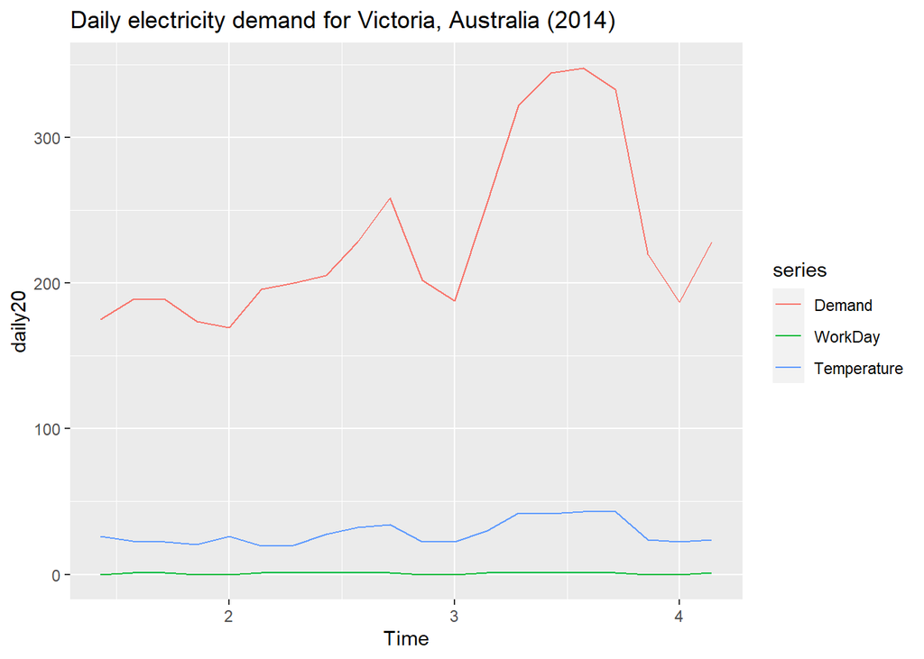

```r
autoplot(daily20, main="Daily electricity demand for Victoria, Australia (2014)")
```

```r
fit_dem <- tslm(Demand ~ Temperature, data = daily20)
fit_dem
```

```
##
## Call:
## tslm(formula = Demand ~ Temperature, data = daily20)
##
## Coefficients:
## (Intercept)  Temperature
##      39.212        6.757
```

```r
summary(fit_dem)
```

```
##
## Call:
## tslm(formula = Demand ~ Temperature, data = daily20)
##
## Residuals:
##     Min      1Q  Median      3Q     Max
## -46.060  -7.117  -1.437  17.484  27.102
##
## Coefficients:
##             Estimate Std. Error t value Pr(>|t|)
## (Intercept)  39.2117    17.9915   2.179   0.0428 *
## Temperature   6.7572     0.6114  11.052 1.88e-09 ***
## ---
## Signif. codes:  0 '***' 0.001 '**' 0.01 '*' 0.05 '.' 0.1 ' ' 1
##
## Residual standard error: 22 on 18 degrees of freedom
## Multiple R-squared:  0.8716, Adjusted R-squared:  0.8644
## F-statistic: 122.1 on 1 and 18 DF,  p-value: 1.876e-09
```

We can see a positive relationship between the demand for electricity and the temperature. When we get closer to time 3, the demand for electricity increases, and the temperature increases too. It seems the positive relationship happens because people use the air-conditioner more when the weather is hotter, which consumes more electricity.

`#` Question 1(b) Produce a residual plot. Is the model adequate? Are there any outliers or influential observations?

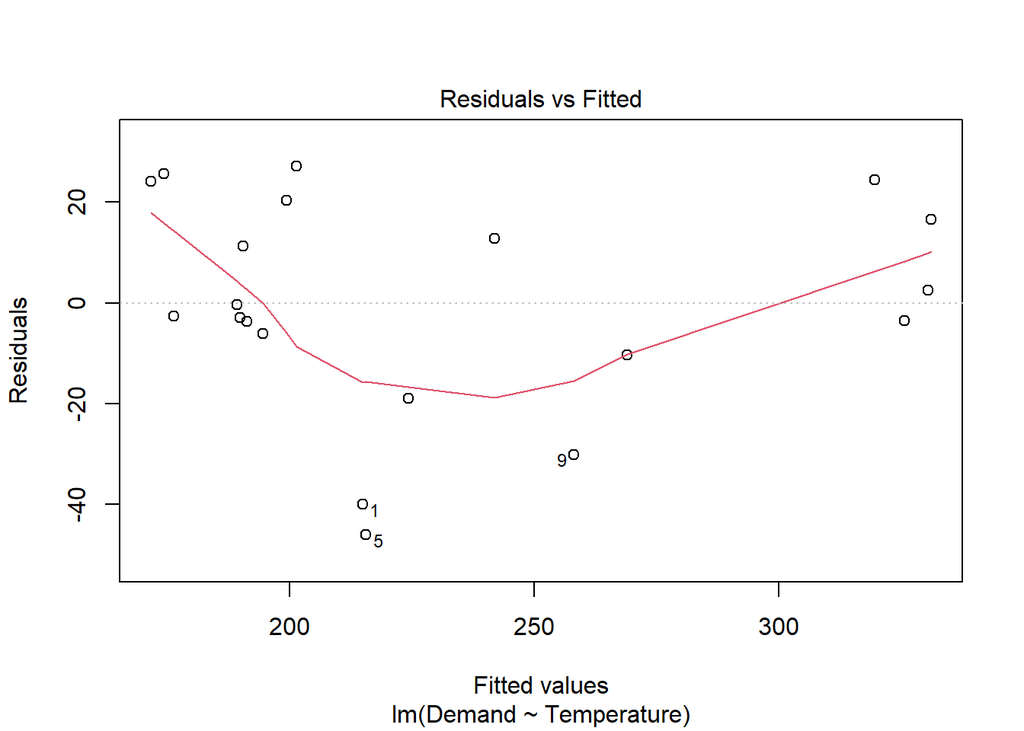

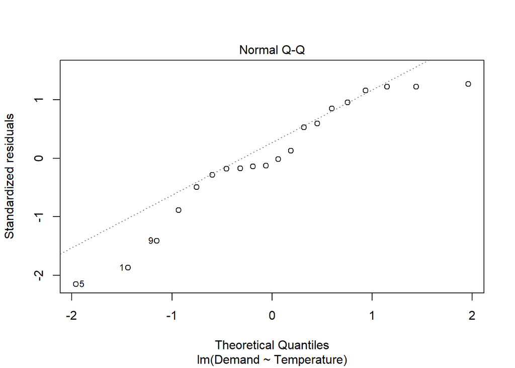

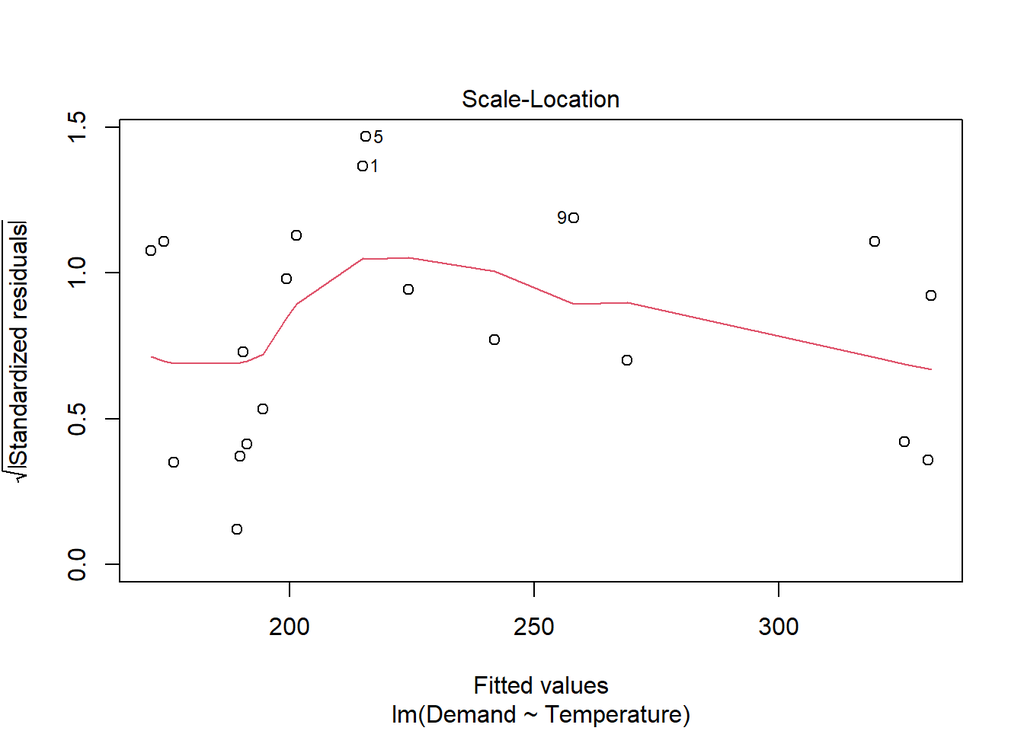

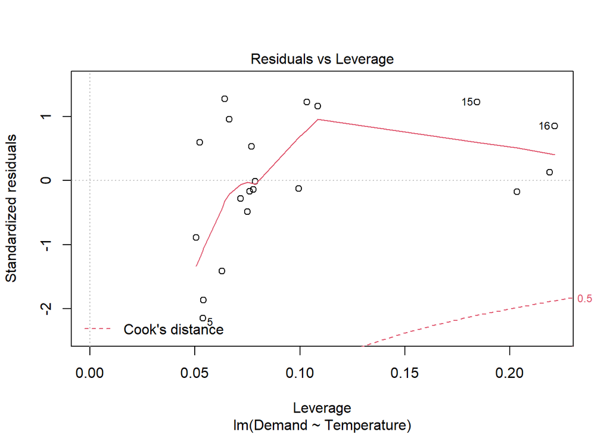

```r
plot(lm(Demand ~ Temperature, data = daily20))
```

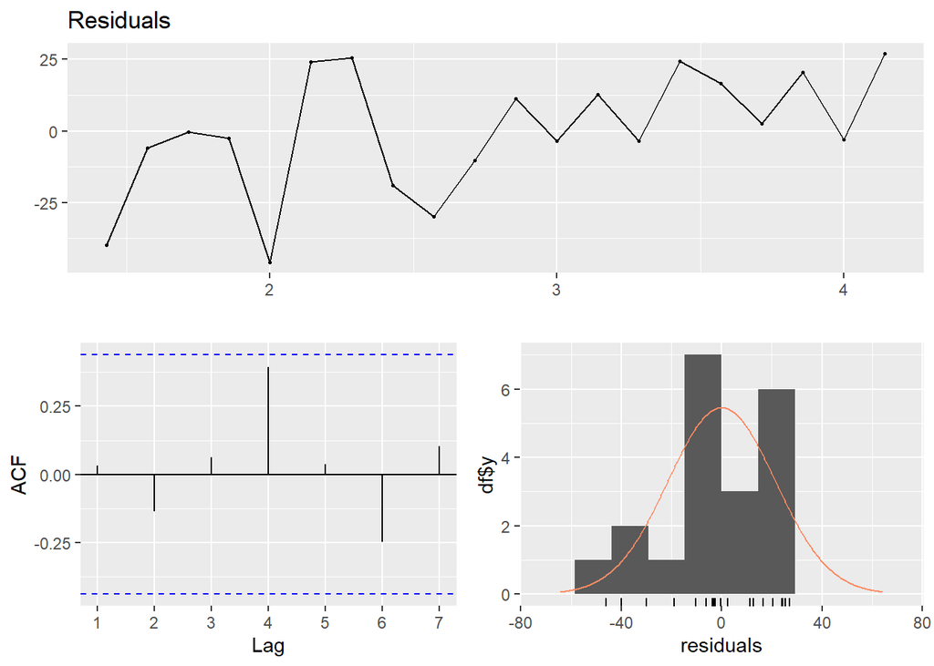

```r
checkresiduals(fit_dem$residuals)
```

From the residual check plot, I think this model is adequate, their residuals aren’t correlated with each other, there are some outlines, but most of the data sets fall in the range, and the residual is not skewed to the right or left.

`#` Question 1(c) Use the model to forecast the electricity demand that you would expect for the next day if the maximum temperature was 15∘, and compare it with the forecast if the with maximum temperature was 35∘.Do you believe these forecasts?

```r
newtemp <- data.frame(Temperature = c(15,35))
forc.tem <- forecast(fit_dem, newdata = newtemp)
forc.tem
```

```
##          Point Forecast    Lo 80    Hi 80     Lo 95    Hi 95
## 4.285714       140.5701 108.6810 172.4591  90.21166 190.9285
## 4.428571       275.7146 245.2278 306.2014 227.57056 323.8586
```

`#` Question 1(d) Give prediction intervals for your forecasts. The following R code will get you started:

```r
# 80% intervals
forc.tem$upper[, 1]
```

```
## Time Series:
## Start = c(4, 3)
## End = c(4, 4)
## Frequency = 7
## [1] 172.4591 306.2014
```

```r
forc.tem$lower[, 1]
```

```
## Time Series:
## Start = c(4, 3)
## End = c(4, 4)
## Frequency = 7
## [1] 108.6810 245.2278
```

```r
# 95% intervals
forc.tem$upper[, 2]
```

```
## Time Series:
## Start = c(4, 3)
## End = c(4, 4)
## Frequency = 7
## [1] 190.9285 323.8586
```

```r
forc.tem$lower[, 2]
```

```
## Time Series:
## Start = c(4, 3)
## End = c(4, 4)
## Frequency = 7
## [1]  90.21166 227.57056
```

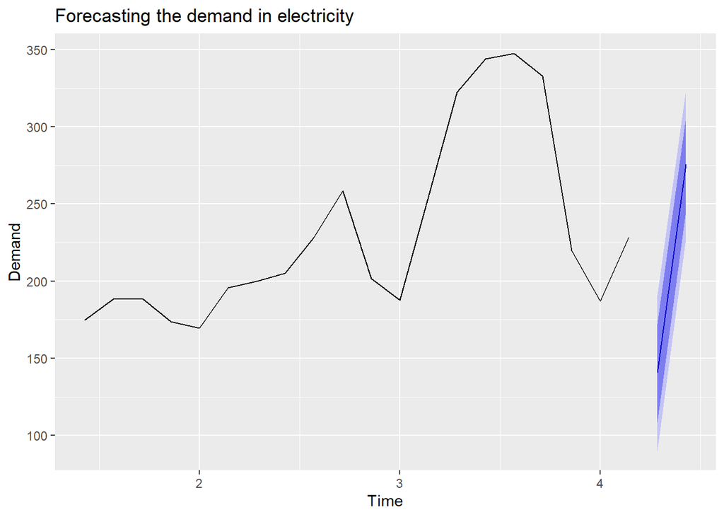

```r
autoplot(forc.tem, main = "Forecasting the demand in electricity")
```

`#` Question 1(e) Plot Demand vs Temperature for all of the available data in electrically. What does this say about your model?

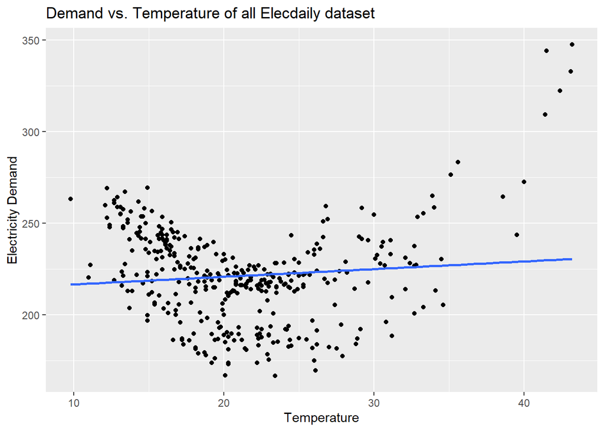

```r
elecdaily %>%
  as.data.frame() %>%
  ggplot(aes(x=Temperature, y=Demand)) +
    ylab("Electricity Demand") +
    xlab("Temperature") +
    ggtitle("Demand vs. Temperature of all Elecdaily dataset")+
    geom_point() +
    geom_smooth(method="lm", se=FALSE)
```

While our model forecast increases demand over time, the all data plot is different from our 20 days data plot, so that could tell our model could be good for the first 20 days, but it couldn’t be good enough for the total data.

## Question 2

Data set`mens400`contains the winning times (in seconds) for the men’s 400 meters final in each Olympic Games from 1896 to 2016.

`#` Question 2(a) Plot the winning time against the year. Describe the main features of the plot.

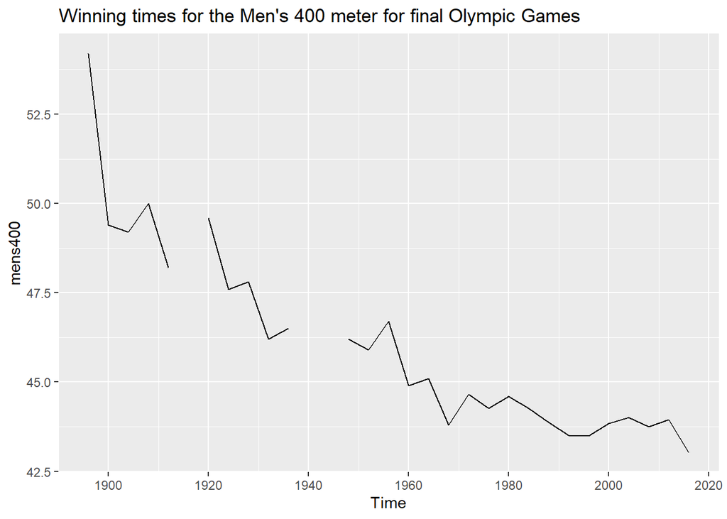

```r
autoplot(mens400, main="Winning times for the Men's 400 meter for final Olympic Games ")
```

We can observe the average time for winning in the Men’s 400-meter Olympic games final keeps decreasing over the years. Also, there are some missing data for some years before 1950.

`#` Question 2(b) Fit a regression line to the data. Obviously the winning times have been decreasing, but at what average rate per year?

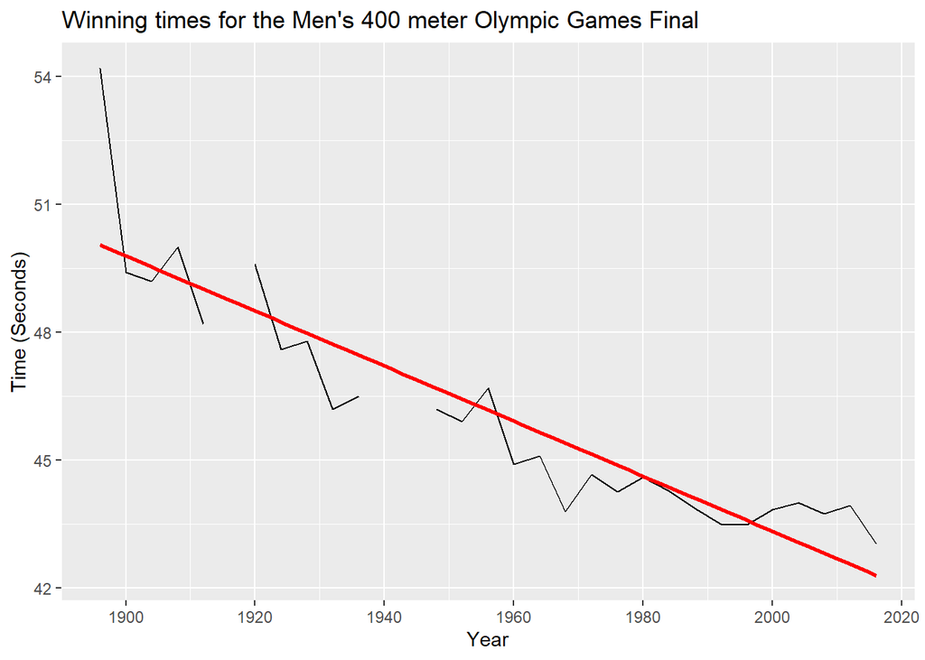

```r
time.400 <- time(mens400)
t <-tslm(mens400 ~ time.400, data=mens400)

#  data regression line
autoplot(mens400,
         main="Winning times for the Men's 400 meter Olympic Games Final",
         ylab="Time (Seconds)",
         xlab="Year") +
  geom_smooth(method="lm", se=FALSE, colour = "red")
```

```r
# The time decreasing rate
t$coefficients[2]
```

```
##    time.400
## -0.06457385
```

The winning times have been decreasing at an average rate of ~ 0.065 seconds per year.

`#` Question 2(c) Plot the residuals against the year. What does this indicate about the suitability of the fitted line?

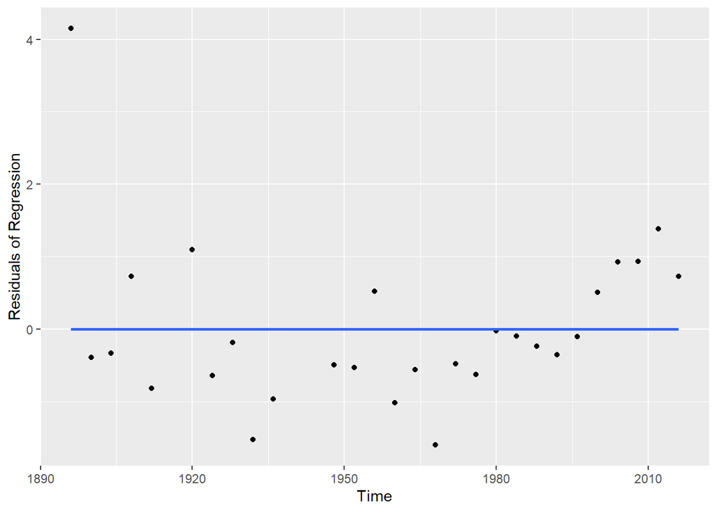

```r
cbind(Time = time.400,
      Residuals = t$residuals) %>%
  as.data.frame() %>%
ggplot(aes(x = Time, y = Residuals)) +
    geom_point() +
    ylab("Residuals of Regression")+
    geom_smooth(method="lm", se=FALSE)
```

`#` Question 2(d) Predict the winning time for the men’s 400 meters final in the 2020 Olympics. Give a prediction interval for your forecasts. What assumptions have you made in these calculations?

```r
LM.mens400 <- lm(
  mens400 ~ time.400,
  data = mens400,
  na.action = na.exclude  # excluding the missing periods
  )
forc_mens400 <- forecast(
  LM.mens400,
  newdata = data.frame(time.400 = 2020)
  )

forc_mens400
```

```
##   Point Forecast    Lo 80    Hi 80    Lo 95    Hi 95
## 1       42.04231 40.44975 43.63487 39.55286 44.53176
```

```r
# 80% intervals
forc_mens400$upper[, 1]
```

```
## [1] 43.63487
```

```r
forc_mens400$lower[, 1]
```

```
## [1] 40.44975
```

```r
# 95% intervals
forc_mens400$upper[, 2]
```

```
## [1] 44.53176
```

```r
forc_mens400$lower[, 2]
```

```
## [1] 39.55286
```

80% interval is ranges from 40.45 to 43.63 95% interval is ranges from 39.55 to 44.53

The assumption we made to take the prediction intervals was the model’s residuals were normally destructed.

## Question 3

Type `easter(ausbeer)` and interpret what you see.

```r
easter(ausbeer)
```

```
##      Qtr1 Qtr2 Qtr3 Qtr4
## 1956 0.67 0.33 0.00 0.00
## 1957 0.00 1.00 0.00 0.00
## 1958 0.00 1.00 0.00 0.00
## 1959 1.00 0.00 0.00 0.00
## 1960 0.00 1.00 0.00 0.00
## 1961 0.33 0.67 0.00 0.00
## 1962 0.00 1.00 0.00 0.00
## 1963 0.00 1.00 0.00 0.00
## 1964 1.00 0.00 0.00 0.00
## 1965 0.00 1.00 0.00 0.00
## 1966 0.00 1.00 0.00 0.00
## 1967 1.00 0.00 0.00 0.00
## 1968 0.00 1.00 0.00 0.00
## 1969 0.00 1.00 0.00 0.00
```

[output cut: 41 more lines]

```r
str(ausbeer)
```

```
##  Time-Series [1:218] from 1956 to 2010: 284 213 227 308 262 228 236 320 272 233 ...
```

What we see in the `easter(ausbeer)` is the quarterly Australian beer production data, is range from the first quarter of 1956 to the second quarter of 2010, the are 218 quarter shoes in the data, the function `easter(ausbeer)` give us victors of zeros and ones or fraction between 0 and 1, 1 is holidays 0 is no holidays, there is the function which means the holidays split between more than one quarter and each quarter takes fraction depending on how many holidays that hold in them.

## Question 4

Express y as a function of x and show that the coefficient β1 is the elasticity coefficient.

> log(y) = β0 + β1log(x) + ε

> β1log(x) = log(y) - β0 - e

> β1 = (log(y) - β0 - e) / log(x)

As we see β1 is a elasticity coefficient beaus it is a ratio of stranger changes in variable (y) to the predictor (x), so if the (x) change by one unit the (y) changes by β1.

## Question 5

The data set fancy concerns the monthly sales figures of a shop which opened in January 1987 and sells gifts, souvenirs, and novelties. The shop is situated on the wharf at a beach resort town in Queensland, Australia. The sales volume varies with the seasonal population of tourists. There is a large influx of visitors to the town at Christmas and for the local surfing festival, held every March since 1988. Over time, the shop has expanded its premises, range of products, and staff

`#` Question 5(a) Produce a time plot of the data and describe the patterns in the graph. Identify any unusual or unexpected fluctuations in the time series.

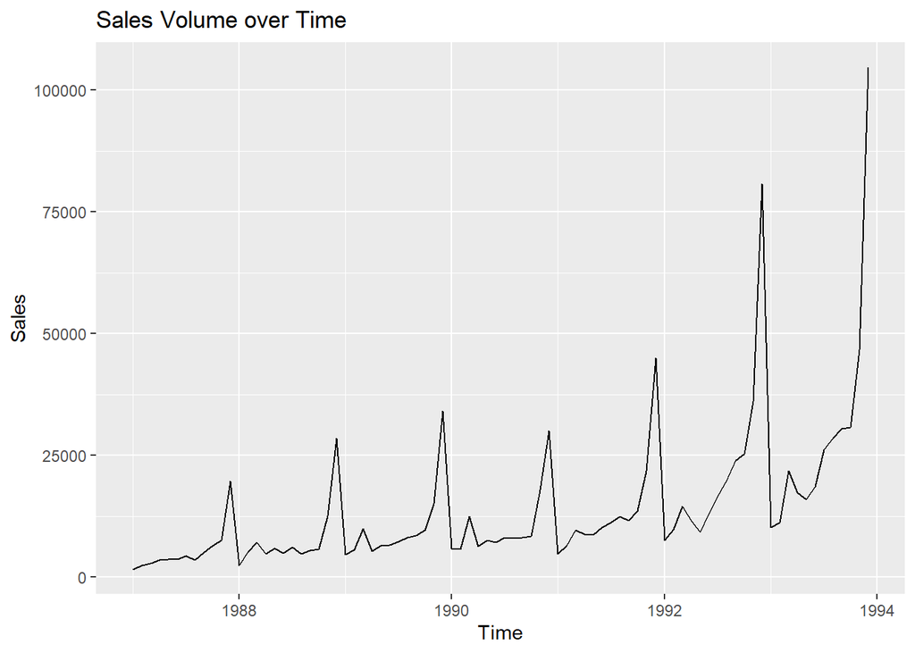

```r
autoplot(fancy, main="Sales Volume over Time", ylab="Sales")
```

`#` Question 5(b) Explain why it is necessary to take logarithms of these data before fitting a model.

There could be heteroscedasticity across the residuals so the variance of the residuals may not be constant and we need the seasonal variations are almost same across the periods to have good fitting , so we use the a transformation like the logarithms to solve that issue.

`#` Question 5(c) Use R to fit a regression model to the logarithms of these sales data with a linear trend, seasonal dummies and a “surfing festival” dummy variable.

```r
# we making "surfing_festival" as dummy variable using time index in fancy. 1 if the year is equal to or above 1988 and the month is March.
Time <- time(fancy)
surfing_festival <- c()
for(i in 1:length(Time)){
  month <- round(12*(Time[i] - floor(Time[i]))) + 1
  year <- floor(Time[i])
  if(year >= 1988 & month == 3){
    surfing_festival[i] <- 1
  } else {
    surfing_festival[i] <- 0
  }
}


# we Use BoxCox power transformation prior to regression formula
tslm.log.fancy <- tslm(
  BoxCox(fancy, 0) ~ trend + season + surfing_festival
  )
summary(tslm.log.fancy)
```

```
##
## Call:
## tslm(formula = BoxCox(fancy, 0) ~ trend + season + surfing_festival)
##
## Residuals:
##      Min       1Q   Median       3Q      Max
## -0.33673 -0.12757  0.00257  0.10911  0.37671
##
## Coefficients:
##                   Estimate Std. Error t value Pr(>|t|)
## (Intercept)      7.6196670  0.0742471 102.626  < 2e-16 ***
## trend            0.0220198  0.0008268  26.634  < 2e-16 ***
## season2          0.2514168  0.0956790   2.628 0.010555 *
## season3          0.2660828  0.1934044   1.376 0.173275
## season4          0.3840535  0.0957075   4.013 0.000148 ***
## season5          0.4094870  0.0957325   4.277 5.88e-05 ***
## season6          0.4488283  0.0957647   4.687 1.33e-05 ***
## season7          0.6104545  0.0958039   6.372 1.71e-08 ***
## season8          0.5879644  0.0958503   6.134 4.53e-08 ***
## season9          0.6693299  0.0959037   6.979 1.36e-09 ***
## season10         0.7473919  0.0959643   7.788 4.48e-11 ***
## season11         1.2067479  0.0960319  12.566  < 2e-16 ***
## season12         1.9622412  0.0961066  20.417  < 2e-16 ***
## surfing_festival 0.5015151  0.1964273   2.553 0.012856 *
## ---
## Signif. codes:  0 '***' 0.001 '**' 0.01 '*' 0.05 '.' 0.1 ' ' 1
##
## Residual standard error: 0.179 on 70 degrees of freedom
## Multiple R-squared:  0.9567, Adjusted R-squared:  0.9487
## F-statistic:   119 on 13 and 70 DF,  p-value: < 2.2e-16
```

`#` Question 5(d) Plot the residuals against time and against the fitted values. Do these plots reveal any problems with the model?

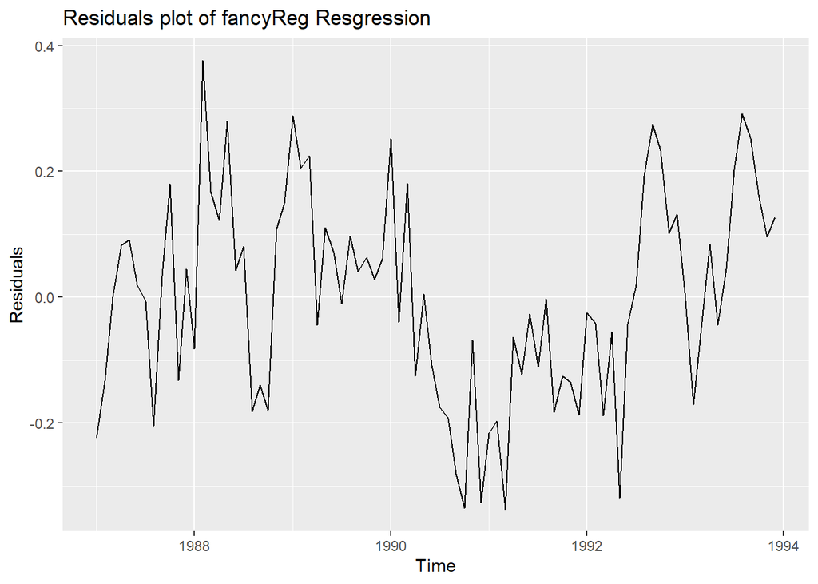

```r
autoplot(tslm.log.fancy$residuals, main="Residuals plot of fancyReg Resgression", ylab="Residuals")
```

The residuals still have pattern in the time, that means correlation between residuals and time winch will creates an autocorrelation issue in our data.

`#` Question 5(e) Do boxplots of the residuals for each month. Does this reveal any problems with the model?

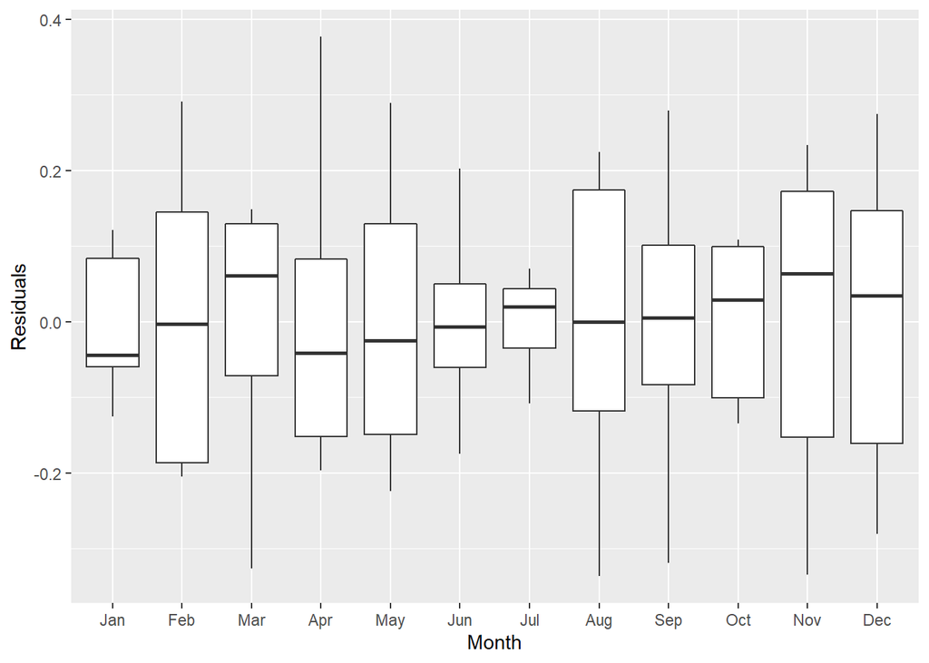

```r
cbind.data.frame(
    Month = factor(
      month.abb[round(12*(Time - floor(Time)) + 1)],
      labels = month.abb,
      ordered = TRUE
    ),
    Residuals = tslm.log.fancy$residuals
    ) %>%
  ggplot(aes(x = Month,
             y = Residuals)) +
    geom_boxplot()
```

`#` Question 5(f) What do the values of the coefficients tell you about each variable?

```r
tslm.log.fancy$coefficients
```

```
##      (Intercept)            trend          season2          season3
##       7.61966701       0.02201983       0.25141682       0.26608280
##          season4          season5          season6          season7
##       0.38405351       0.40948697       0.44882828       0.61045453
##          season8          season9         season10         season11
##       0.58796443       0.66932985       0.74739195       1.20674790
##         season12 surfing_festival
##       1.96224123       0.50151509
```

`#` Question 5(g) What does the Breusch-Godfrey test tell you about your model?

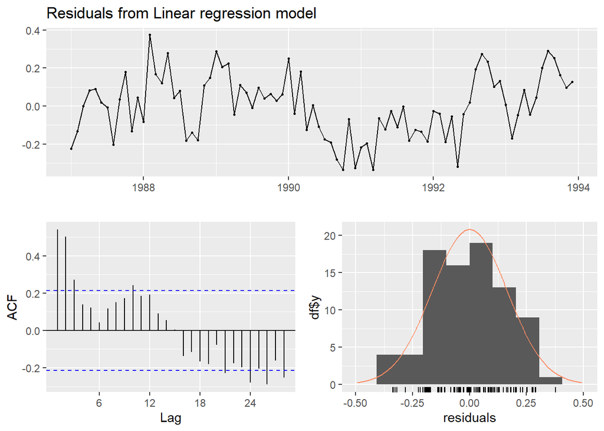

```
##
##  Breusch-Godfrey test for serial correlation of order up to 17
##
## data:  Residuals from Linear regression model
## LM test = 37.954, df = 17, p-value = 0.002494
```

```r
checkresiduals(tslm.log.fancy)
```

The residuals could be correlated with each other. The p-value = 0.002494 lower than 0.5 thats mean residuals are not white noise so probably additional covariates are needed. Autocorrelation plot shows a significant spike at many lags.

`#` Question 5(h) Regardless of your answers to the above questions, use your regression model to predict the monthly sales for 1994, 1995, and 1996. Produce prediction intervals for each of your forecasts.

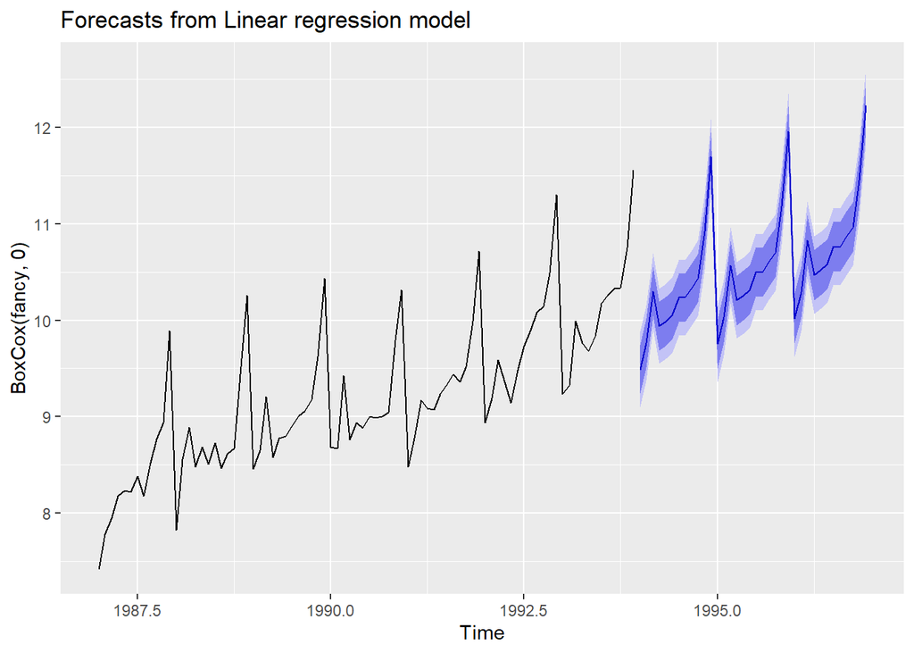

```r
future.fancy <- rep(0, 36) # 3years* 12 month =36
for(i in 1:36){
  if(i %% 12 == 3){
    future.fancy[i] <- 1
  }
}
# make future data as time series.
future.fancy <- ts(data = future.fancy,
                   start = 1994,
                   end = c(1996, 12),
                   frequency = 12)
# The forecast
fc.tslm.log.fancy <- forecast(
  tslm.log.fancy,
  newdata = data.frame(Time = time(future.fancy),
                       surfing_festival = future.fancy)
)
# plotting hte forecast
autoplot(fc.tslm.log.fancy)
```

```r
# show prediction interval
fc.tslm.log.fancy
```

```
##          Point Forecast     Lo 80     Hi 80     Lo 95    Hi 95
## Jan 1994       9.491352  9.238522  9.744183  9.101594  9.88111
## Feb 1994       9.764789  9.511959 10.017620  9.375031 10.15455
## Mar 1994      10.302990 10.048860 10.557120  9.911228 10.69475
## Apr 1994       9.941465  9.688635 10.194296  9.551707 10.33122
## May 1994       9.988919  9.736088 10.241749  9.599161 10.37868
## Jun 1994      10.050280  9.797449 10.303110  9.660522 10.44004
## Jul 1994      10.233926  9.981095 10.486756  9.844168 10.62368
## Aug 1994      10.233456  9.980625 10.486286  9.843698 10.62321
## Sep 1994      10.336841 10.084010 10.589671  9.947083 10.72660
## Oct 1994      10.436923 10.184092 10.689753 10.047165 10.82668
## Nov 1994      10.918299 10.665468 11.171129 10.528541 11.30806
## Dec 1994      11.695812 11.442981 11.948642 11.306054 12.08557
## Jan 1995       9.755590  9.499844 10.011336  9.361338 10.14984
## Feb 1995      10.029027  9.773281 10.284773  9.634775 10.42328
## Mar 1995      10.567228 10.310518 10.823938 10.171489 10.96297
## Apr 1995      10.205703  9.949957 10.461449  9.811451 10.59996
## May 1995      10.253157  9.997411 10.508903  9.858904 10.64741
## Jun 1995      10.314518 10.058772 10.570264  9.920265 10.70877
## Jul 1995      10.498164 10.242418 10.753910 10.103911 10.89242
## Aug 1995      10.497694 10.241948 10.753440 10.103441 10.89195
## Sep 1995      10.601079 10.345333 10.856825 10.206826 10.99533
## Oct 1995      10.701161 10.445415 10.956907 10.306908 11.09541
## Nov 1995      11.182537 10.926791 11.438282 10.788284 11.57679
## Dec 1995      11.960050 11.704304 12.215796 11.565797 12.35430
## Jan 1996      10.019828  9.760564 10.279093  9.620151 10.41951
## Feb 1996      10.293265 10.034000 10.552530  9.893588 10.69294
## Mar 1996      10.831466 10.571566 11.091365 10.430810 11.23212
## Apr 1996      10.469941 10.210677 10.729206 10.070264 10.86962
## May 1996      10.517395 10.258130 10.776659 10.117718 10.91707
## Jun 1996      10.578756 10.319491 10.838021 10.179079 10.97843
## Jul 1996      10.762402 10.503137 11.021667 10.362725 11.16208
## Aug 1996      10.761932 10.502667 11.021196 10.362254 11.16161
## Sep 1996      10.865317 10.606052 11.124582 10.465640 11.26499
## Oct 1996      10.965399 10.706134 11.224664 10.565722 11.36508
## Nov 1996      11.446774 11.187510 11.706039 11.047097 11.84645
## Dec 1996      12.224288 11.965023 12.483552 11.824611 12.62396
```

`#` Question 5(i) Transform your predictions and intervals to obtain predictions and intervals for the raw data.

```r
fancyTrans <- (BoxCox(fancy, 0))
forecast(fancyTrans)
```

```
##          Point Forecast     Lo 80     Hi 80     Lo 95     Hi 95
## Jan 1994       9.674641  9.464046  9.885235  9.352565  9.996717
## Feb 1994       9.958925  9.733371 10.184479  9.613970 10.303880
## Mar 1994      10.439733 10.200143 10.679323 10.073312 10.806155
## Apr 1994      10.121042  9.868185 10.373898  9.734331 10.507752
## May 1994      10.157291  9.891822 10.422759  9.751292 10.563289
## Jun 1994      10.227196  9.949682 10.504711  9.802774 10.651618
## Jul 1994      10.403289 10.114223 10.692356  9.961200 10.845378
## Aug 1994      10.382661 10.082480 10.682842  9.923574 10.841748
## Sep 1994      10.518849 10.207944 10.829754 10.043361 10.994337
## Oct 1994      10.612257 10.290980 10.933534 10.120906 11.103608
## Nov 1994      11.108401 10.777070 11.439732 10.601674 11.615129
## Dec 1994      11.898748 11.557653 12.239843 11.377088 12.420408
## Jan 1995       9.985303  9.634703 10.335903  9.449107 10.521499
## Feb 1995      10.269587  9.909735 10.629440  9.719240 10.819934
## Mar 1995      10.750396 10.381517 11.119274 10.186244 11.314547
## Apr 1995      10.431704 10.054009 10.809399  9.854070 11.009338
## May 1995      10.467953 10.081638 10.854268  9.877135 11.058770
## Jun 1995      10.537858 10.143107 10.932610  9.934137 11.141579
## Jul 1995      10.713952 10.310934 11.116969 10.097590 11.330314
## Aug 1995      10.693323 10.282201 11.104445 10.064567 11.322080
## Sep 1995      10.829511 10.410437 11.248586 10.188592 11.470430
## Oct 1995      10.922919 10.496035 11.349803 10.270057 11.575781
## Nov 1995      11.419063 10.984506 11.853621 10.754465 12.083661
## Dec 1995      12.209410 11.767308 12.651512 11.533273 12.885547
```